# A1 New: Exploration and Cleaning of Dataset

Michelle Lin

12 March 2024

## IMPORT DATA AND INITIAL EXPLORATION

### Set Global variables and constants

```r
# Set GEOID
GEOID <- "GSE160230"

## File location
workingDir <- file.path(getwd())
```

### Study Background Information

The study chosen for this project is “hPSC-derived Airway Organoids-based Screen Reveals the Role of HIF1/ Glycolysis Axis in SARS-CoV-2 Infection” published in 2021 by Duan et al.(Duan et al. 2021)

The authors conducted a study in human pluripotent stem cell (hPSC) derived airway organoids - (hPSC-AO) where they studied the molecular mechanism behind SARS-Cov-2 infections and the differential expression of different components of the pathways when treated with GW6571.

The following is a summary of the study chosen for this assignment.

```r
# get information for study

gse <- GEOquery::getGEO(GEOID, GSEMatrix = FALSE)
currentGPL <- names(GEOquery::GPLList(gse))[1]
currentGPLInfo <- GEOquery::Meta(GEOquery::getGEO(currentGPL))
```

**GEO ID of data set:** GSE160230

**Organism:** Homo sapiens

**Submission Date:** Oct 27 2020

**Last Updated:** Oct 01 2023

**Brief Summary of data set:** SARS-CoV-2, the virus causing recently pandemic, primarily infects the respiratory tract. There is an urgent need to develop platforms using disease relevant human cells to dissect the molecular mechanism regulating SARS-CoV-2 infection and perform drug screen. Here, we derived airway organoids from human pluripotent stem cells (hPSC-AO). The hPSC-AOs, particularly ciliated cells, express ACE2 and are permissive to SARS-CoV-2 infection. Using hPSC-AOs, we performed a high content screen and identified GW6471, which blocks SARS-CoV-2 infection. RNA-seq analysis suggested that GW6471 blocking SARS-CoV-2 infection by inhibiting HIF1α, which is further validated by chemotin, another HIF1α inhibitor. Furthermore, metabolic profiling identified that the downregulation of glycolysis upon GW6471 treatment, which is further validated by RNA-seq. Finally, xanthohumol, a prenylated flavonoid suppressing fatty acid and cholesterol biosynthesis, blocks SARS-CoV-2 infection. Together, we applied the high content screen, RNA-seq and metabolic profiling to define the key role of HIF1α-glycolysis axis in SARS-CoV-2 infection, which provides a target pathway for anti-viral drug development.

**Platform:** Illumina NovaSeq 6000 (Homo sapiens)

**Platform Last Updated:** Nov 05 2018

### Get Expression Data Files

```r
# Set Up + Download Data if not present

filesSupp <- GEOquery::getGEOSuppFiles(GEOID, fetch_files= FALSE)

fileMissing <- filesSupp$fname[!unlist(
  lapply(filesSupp$fname, FUN=function(x){
    file.exists(
      file.path(workingDir,GEOID,x))}))]

if(length(fileMissing) > 0){
  for(i in seq_along(fileMissing)){
    # get the supplementary files
    sfiles = GEOquery::getGEOSuppFiles(GEOID,
                                       baseDir = workingDir,
                                       fetch_files = TRUE)
  }
}
```

The supplementary files found in this dataset are:

GSE160230_raw_counts.hPSC_AO.downsample.txt.gz, GSE160230_raw_counts.hPSC_AO.txt.gz, GSE160230_raw_counts.hPSC_CO.txt.gz

For this study, we will pay particular attention to the “GSE160230_raw_counts.hPSC_AO.downsample.txt” i*n particular.

There were three conditions observed in this study - **3 mock samples** - untreated and uninfected, **3 control samples** - untreated and infected and **3 GW_treated samples** - treated and infected samples. Due to the difference in higher observed viral counts and hence, lower human gene counts in SARS-Cov2 infected samples, the raw counts in the uninfected samples (mock and treated) was down-sampled so that the median human gene count was comparable to that in the infected samples. (Duan et al. 2021)

## 1. Load and Preprocess Data

```r
# Read data files
dataFile <- "GSE160230_raw_counts.hPSC_AO.downsample.txt.gz"

aoCtrlTreatMat <- utils::read.table(
  file.path(workingDir, GEOID, dataFile),
  header = TRUE,
  check.names = TRUE
)
```

The dataset is of shape (48815, 9) with 48815 genes and 9 samples- 3 mock (m), 3 untreated and infected (d), 3 treated and infected (gw). A preview of the dataset can be seen below:

```r
knitr::kable(aoCtrlTreatMat[1:7, 1:9], format = "html")
```

|  | airway_m_1 | airway_m_2 | airway_m_3 | airway_d_1 | airway_d_2 | airway_d_3 | airway_gw_1 | airway_gw_2 | airway_gw_3 |
| --- | --- | --- | --- | --- | --- | --- | --- | --- | --- |
| ENSG00000000003 | 1832 | 1884 | 1733 | 1714 | 2354 | 1521 | 1545 | 1678 | 1608 |
| ENSG00000000005 | 1 | 1 | 3 | 5 | 2 | 1 | 0 | 3 | 1 |
| ENSG00000000419 | 517 | 456 | 488 | 459 | 652 | 430 | 519 | 525 | 481 |
| ENSG00000000457 | 257 | 260 | 251 | 245 | 346 | 322 | 230 | 250 | 260 |
| ENSG00000000460 | 225 | 212 | 197 | 178 | 366 | 201 | 104 | 133 | 127 |
| ENSG00000000938 | 0 | 0 | 0 | 4 | 2 | 2 | 9 | 3 | 6 |
| ENSG00000000971 | 92 | 126 | 143 | 365 | 257 | 311 | 341 | 276 | 672 |

```r
# Initial Pre-processing of data
any(is.na(aoCtrlTreatMat))
```

```
[1] FALSE
```

There were no missing values found in this dataset.

## HUGO GENE SYMBOL MATCH

The following is a table of some of the Ensembl human datasets.

```r
library(biomaRt)

# Ensembl
ensembl <- biomaRt::useMart("ensembl")
datasetEnsembl <- biomaRt::listDatasets(ensembl)
knitr::kable(head(datasetEnsembl[grep(datasetEnsembl$dataset, pattern = "sapiens"), ]), format = "html")
```

|  | dataset | description | version |
| --- | --- | --- | --- |
| 80 | hsapiens_gene_ensembl | Human genes (GRCh38.p14) | GRCh38.p14 |

```r
ensembl <- biomaRt::useDataset("hsapiens_gene_ensembl", mart=ensembl)
```

```r
# filters
biomartHumanFilters <- biomaRt::listFilters(ensembl)
knitr::kable(biomartHumanFilters[
  grep(biomartHumanFilters$name, pattern="ensembl"), ], format = "html")
```

|  | name | description |
| --- | --- | --- |
| 53 | ensembl_gene_id | Gene stable ID(s) [e.g. ENSG00000000003] |
| 54 | ensembl_gene_id_version | Gene stable ID(s) with version [e.g. ENSG00000000003.16] |
| 55 | ensembl_transcript_id | Transcript stable ID(s) [e.g. ENST00000000233] |
| 56 | ensembl_transcript_id_version | Transcript stable ID(s) with version [e.g. ENST00000000233.10] |
| 57 | ensembl_peptide_id | Protein stable ID(s) [e.g. ENSP00000000233] |
| 58 | ensembl_peptide_id_version | Protein stable ID(s) with version [e.g. ENSP00000000233.5] |
| 59 | ensembl_exon_id | Exon ID(s) [e.g. ENSE00000000001] |

```r
# create conversion object if not present and save
stashConversion <- "ensemblHUGOConversion.rds"
ids2convert <- rownames(aoCtrlTreatMat)
if(file.exists(stashConversion)){
  conversionLink <- readRDS(stashConversion)
} else {
  conversionLink <- getBM(attributes = c("ensembl_gene_id", "hgnc_symbol"),
                          filters = c("ensembl_gene_id"),
                          values = ids2convert,
                          mart =ensembl )
  saveRDS(conversionLink, stashConversion)
}


# Merge identifier with original table
objAnnotated <- merge(conversionLink, aoCtrlTreatMat, by.x = 1, by.y = 0, all.y = TRUE)
```

### Remove Unmapped Genes

```r
# Find the number of genes that remained unmatched

## number of genes mapped
mappedGenes <- length(which(rownames(aoCtrlTreatMat) %in%
               conversionLink$ensembl_gene_id))

## total num_genes
totalGenes <- nrow(aoCtrlTreatMat)

## number of genes missing
unmatchedGenes <- totalGenes - mappedGenes
```

There were 45887 mapped human genes of the total 48815 transcribed and 2928 genes remained unmatched. This is potentially due to 2 main reasons - outdated Ensembl mappings and the remaining genes being viral genes which we are not interested in.

```r
## show table
unmatched <- objAnnotated[which(is.na(objAnnotated$hgnc_symbol)), ]
unmatchedEg <- knitr::kable(objAnnotated[which(is.na(objAnnotated$hgnc_symbol))[1:5], 1:5], type = "html")

matchObj <- objAnnotated[!(is.na(objAnnotated$hgnc_symbol)), ]
```

There were 2928 genes that remained unmatched. Some examples of which are:

|  | ensembl_gene_id | hgnc_symbol | airway_m_1 | airway_m_2 | airway_m_3 |
| --- | --- | --- | --- | --- | --- |
| 113 | ENSG00000005955 | NA | 1632 | 1648 | 1662 |
| 125 | ENSG00000006074 | NA | 1 | 0 | 1 |
| 126 | ENSG00000006075 | NA | 109 | 123 | 127 |
| 127 | ENSG00000006114 | NA | 963 | 1032 | 1038 |
| 378 | ENSG00000017373 | NA | 36 | 40 | 39 |

.

### Combine Rows with the same Gene Names

```r
# create a table for HUGO genes on row and sample on column
uniqGenes <- length(unique(matchObj$hgnc_symbol))
uniqEnblIDs <- length(unique(matchObj$ensembl_gene_id))
```

There were found to be 33834 unique gene mappings and 45887 ensembl gene IDs mapped, indicating that several of the Ensembl gene IDs mapped to the same gene. Hence, next, we will be aggregating these rows.

```r
# Aggregate duplicated genes

## find duplicated genes and unique genes
duplicatedGenes <- unique(matchObj$hgnc_symbol[duplicated(matchObj$hgnc_symbol)])
uniqueGenes <- unique(matchObj$hgnc_symbol)

## aggregation and remove un-named gene
matchObj <- matchObj[, -which(colnames(matchObj) == "ensembl_gene_id")]
aggmatchObj <- aggregate(.~hgnc_symbol, data = matchObj, FUN=sum)
aggmatchObj <- aggmatchObj[-c(aggmatchObj$hgnc_symbol == ""), ]

## save intermediary objects
saveRDS(aggmatchObj, "AggregatedDataset.RDS")
write.csv(aggmatchObj, "AggregatedDataset.csv")
```

Our final dataset after cleaning the data results in a dataset of shape (33833, 10), that is 33833 labelled genes and expressions values for 9 samples - 3 mock, 3 untreated and infected, 3 treated and infected.

## DATA CLEANING AND PRE-PROCESSING

### Remove Low Expression Genes

```r
# choose min number of samples
min_samples <- 3

aggMat <- as.matrix(aggmatchObj)
rownames(aggMat) <- aggMat[, 1]
aggMat <- aggMat[,-1]

aggMat <- trimws(aggMat)
write.csv(aggMat, "aggregated_matrix.csv")

for (ri in seq_along(rownames(aggMat))){
  for (cj in seq_along(colnames(aggMat))){
    aggMat[ri, cj] <- as.integer(aggMat[ri, cj])
  }
}

intMat <- matrix(as.integer(aggMat), nrow = nrow(aggMat), ncol = ncol(aggMat))
colnames(intMat) <- c("Mock1", "Mock2", "Mock3", "Control1", "Control2", "Control3", "GW-Treated1", "GW-Treated2", "GW-Treated3")
rownames(intMat) <- rownames(aggMat)

satisfied <- rowSums(edgeR::cpm(int_matrix) > 1) >= min_samples
cleanData <- intMat[satisfied, ]

write.csv(cleanData, "CleanDataset.csv")
saveRDS(cleanData, "CleanDataset.RDS")
```

From the above, we removed 1.9162^{4} genes due to low expression values.

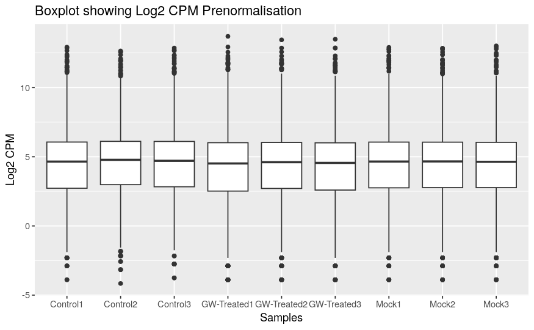

```r
# Plot the data before and after
library(hrbrthemes)
library(ggplot2)


## BOXPLOT
## Add 1 to each value in the cleanData to prevent -inf errors for 0 expression
dataAdd1 <- cleanData + 1
dataLog <- log2(edgeR::cpm(dataAdd1))

dfLog <- as.data.frame(dataLog)
dfLog$Gene <- rownames(dfLog)
dfLogLonger <- tidyr::pivot_longer(dfLog, cols = -Gene, names_to = "Sample", values_to = "Log2CPM")

ggplot2::ggplot(dfLogLonger, aes(x = Sample, y = Log2CPM)) +
  geom_boxplot() +
  labs(x = "Samples", y = "Log2 CPM") +
  ggtitle("Boxplot showing Log2 CPM Prenormalisation")
```

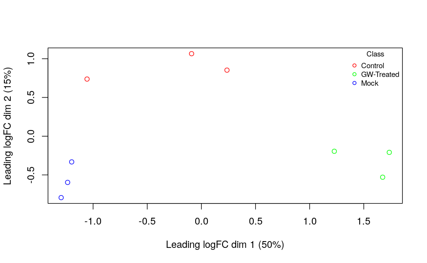

```r
## MDS PLOT
limma::plotMDS(log2(cleanData), labels=NULL, pch=1,
               col = c("red", "green", "blue")[factor(groups)])

legend("topright",
  legend=levels(factor(groups)),
  pch=c(1), col= c("red", "green","blue"),title="Class",
  bty = 'n', cex = 0.75)
```

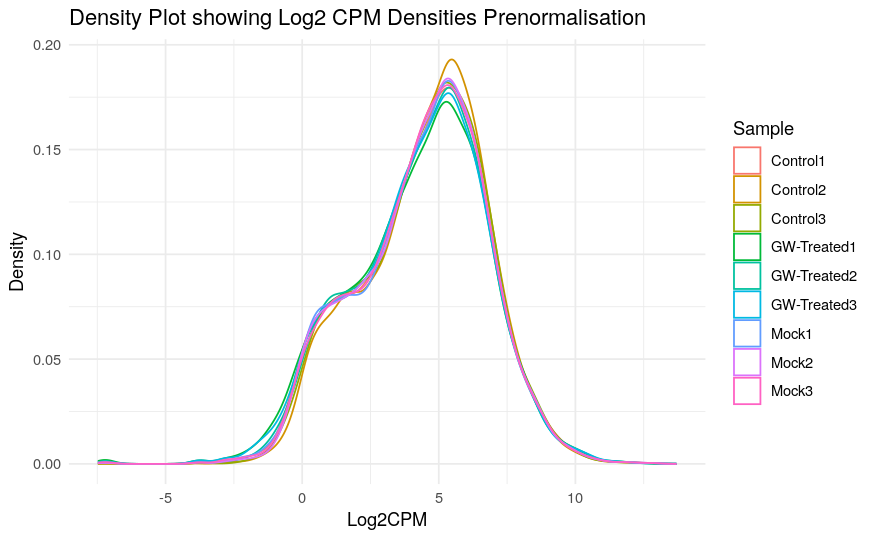

```r
## DENSITY PLOT
## Add 0.1 to each value in the cleanData to prevent 0 expression error
dataAddp1 <- cleanData + 0.1
dataLogp1 <- log2(edgeR::cpm(dataAddp1))

dfLogp1 <- as.data.frame(dataLogp1)
dfLogp1$Gene <- rownames(dfLogp1)
dfLogLongerp1 <- tidyr::pivot_longer(dfLogp1, cols = -Gene, names_to = "Sample", values_to = "Log2CPM")
ggplot(dfLogLongerp1, aes(x = Log2CPM, color=Sample)) +
  geom_density() +
  labs(x = "Log2CPM", y = "Density") +
  theme_minimal() +
  ggtitle("Density Plot showing Log2 CPM Densities Prenormalisation")
```

## Normalisation

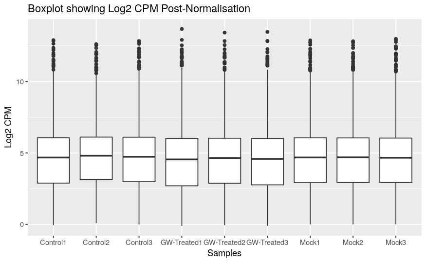

```r
# Plot for the before and after
groups <- c("Mock", "Mock", "Mock", "Control", "Control", "Control", "GW-Treated", "GW-Treated", "GW-Treated")

ofDGE <- edgeR::DGEList(counts = cleanData, group=groups, remove.zeros = TRUE)
ofDGE <- edgeR::calcNormFactors(ofDGE)

normalised <- edgeR::cpm(ofDGE)
saveRDS(normalised, "NormalisedData.RDS")
write.csv(normalised, "normalised_data.csv")


## BOXPLOT
### Adding 1 to prevent 0 expression from going to -inf
dataAdd1n <- normalised + 1
dataLogn <- log2(edgeR::cpm(dataAdd1n))

dfLogn <- as.data.frame(dataLogn)
dfLogn$Gene <- rownames(dfLogn)
dfLogLongern <- tidyr::pivot_longer(dfLogn, cols = -Gene, names_to = "Sample", values_to = "Log2CPM")

ggplot2::ggplot(dfLogLongern, aes(x = Sample, y = Log2CPM)) +
  geom_boxplot() +
  labs(x = "Samples", y = "Log2 CPM") +
  ggtitle("Boxplot showing Log2 CPM Post-Normalisation")
```

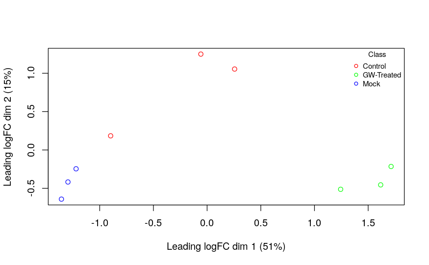

```r
## MDS PLOT
limma::plotMDS(log2(normalised), labels=NULL, pch=1,
               col = c("red", "green", "blue")[factor(groups)])

legend("topright",
  legend=levels(factor(groups)),
  pch=c(1), col= c("red", "green","blue"),title="Class",
  bty = 'n', cex = 0.75)
```

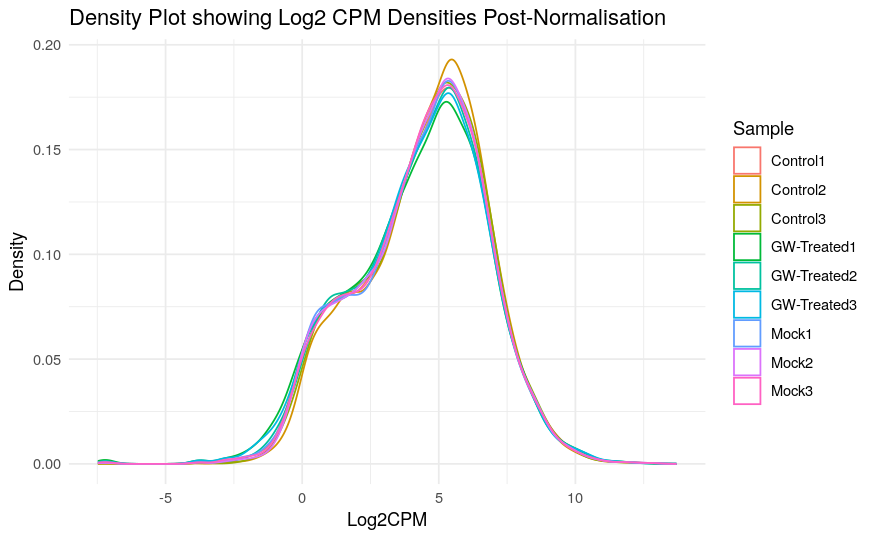

```r
## DENSITY PLOT
## Add 0.1 to each value in the normalised data to prevent 0 expression error
dataAddp1n <- normalised + 0.1
dataLogp1n <- log2(edgeR::cpm(dataAddp1n))

dfLogp1n <- as.data.frame(dataLogp1n)
dfLogp1n$Gene <- rownames(dfLogp1n)
dfLogLongerp1n <- tidyr::pivot_longer(dfLogp1n, cols = -Gene, names_to = "Sample", values_to = "Log2CPM")
ggplot(dfLogLongerp1, aes(x = Log2CPM, color=Sample)) +
  geom_density() +
  labs(x = "Log2CPM", y = "Density") +
  theme_minimal() +
  ggtitle("Density Plot showing Log2 CPM Densities Post-Normalisation")
```

## BIBLIOGRAPHY

Duan, Xiaohua, Xuming Tang, Manoj S Nair, Tuo Zhang, Yunping Qiu, Wei Zhang, Pengfei Wang, et al. 2021. “An Airway Organoid-Based Screen Identifies a Role for the HIF1$\alpha$-Glycolysis Axis in SARS-CoV-2 Infection.” *Cell Reports* 37 (6).